# Daily Exercise 11/12

Author

Ava Madalinski

Published

March 7, 2025

Part 1:

```r
library(tidyverse)
library(visdat)
library(ggpubr)
library(ggplot2)

str(airquality)
```

```
'data.frame':   153 obs. of  6 variables:
 $ Ozone  : int  41 36 12 18 NA 28 23 19 8 NA ...
 $ Solar.R: int  190 118 149 313 NA NA 299 99 19 194 ...
 $ Wind   : num  7.4 8 12.6 11.5 14.3 14.9 8.6 13.8 20.1 8.6 ...
 $ Temp   : int  67 72 74 62 56 66 65 59 61 69 ...
 $ Month  : int  5 5 5 5 5 5 5 5 5 5 ...
 $ Day    : int  1 2 3 4 5 6 7 8 9 10 ...
```

```r
summary(airquality)
```

```
     Ozone           Solar.R           Wind             Temp
 Min.   :  1.00   Min.   :  7.0   Min.   : 1.700   Min.   :56.00
 1st Qu.: 18.00   1st Qu.:115.8   1st Qu.: 7.400   1st Qu.:72.00
 Median : 31.50   Median :205.0   Median : 9.700   Median :79.00
 Mean   : 42.13   Mean   :185.9   Mean   : 9.958   Mean   :77.88
 3rd Qu.: 63.25   3rd Qu.:258.8   3rd Qu.:11.500   3rd Qu.:85.00
 Max.   :168.00   Max.   :334.0   Max.   :20.700   Max.   :97.00
 NA's   :37       NA's   :7
     Month            Day
 Min.   :5.000   Min.   : 1.0
 1st Qu.:6.000   1st Qu.: 8.0
 Median :7.000   Median :16.0
 Mean   :6.993   Mean   :15.8
 3rd Qu.:8.000   3rd Qu.:23.0
 Max.   :9.000   Max.   :31.0
```

```r
airquality <- airquality |>
  distinct()
```

```r
shapiro.test(airquality$Ozone)
```

```
    Shapiro-Wilk normality test

data:  airquality$Ozone
W = 0.87867, p-value = 2.79e-08
```

```r
shapiro.test(airquality$Wind)
```

```
    Shapiro-Wilk normality test

data:  airquality$Wind
W = 0.98575, p-value = 0.1178
```

```r
shapiro.test(airquality$Solar.R)
```

```
    Shapiro-Wilk normality test

data:  airquality$Solar.R
W = 0.94183, p-value = 9.492e-06
```

```r
shapiro.test(airquality$Temp)
```

```
    Shapiro-Wilk normality test

data:  airquality$Temp
W = 0.97617, p-value = 0.009319
```

The purpose of the Shapiro-Wilks test is to test whether or not the data is normally distributed. the null hypothesis is that the data is normally distributed and the alternative hypothesis is that the data is not normally distributed. The p-values indicate that all of the variables, except for wind are not normally distributed as they are all lower than 0.05. Wind’s p-value is higher than 0.05, therefore this variable is normally distributed.

Part 2:

```r
airquality <- airquality |>
  mutate(Season = case_when(
    Month %in% c(11, 12, 1) ~ "Winter",
    Month %in% c(2, 3, 4) ~ "spring",
    Month %in% c(5, 6, 7) ~ "Summer",
    Month %in% c(8, 9, 10) ~ "Fall"
  ))
print(airquality)
```

```
    Ozone Solar.R Wind Temp Month Day Season
1      41     190  7.4   67     5   1 Summer
2      36     118  8.0   72     5   2 Summer
3      12     149 12.6   74     5   3 Summer
4      18     313 11.5   62     5   4 Summer
5      NA      NA 14.3   56     5   5 Summer
6      28      NA 14.9   66     5   6 Summer
7      23     299  8.6   65     5   7 Summer
8      19      99 13.8   59     5   8 Summer
9       8      19 20.1   61     5   9 Summer
10     NA     194  8.6   69     5  10 Summer
11      7      NA  6.9   74     5  11 Summer
12     16     256  9.7   69     5  12 Summer
13     11     290  9.2   66     5  13 Summer
14     14     274 10.9   68     5  14 Summer
```

[output cut: 139 more lines]

```r
season_count <- table(airquality$Season)
print(season_count)
```

```
  Fall Summer
    61     92
```

Part 3:

```r
library(tidymodels)
(recipe <- recipe(Ozone ~ Temp + Solar.R + Wind + Season,
                  data = airquality) |>
   step_impute_mean(all_numeric_predictors()) |>
   step_dummy(all_factor_predictors()) |>
   step_normalize(all_numeric_predictors()))
```

```
── Recipe ──────────────────────────────────────────────────────────────────────
```

```
── Inputs
```

```
Number of variables by role
```

```
outcome:   1
predictor: 4
```

```
── Operations
```

```
• Mean imputation for: all_numeric_predictors()
```

```
• Dummy variables from: all_factor_predictors()
```

```
• Centering and scaling for: all_numeric_predictors()
```

```r
prep_recipe <- prep(recipe, training = airquality)

normalized_data <- bake(prep_recipe, new_data = NULL) |>
  drop_na()

print(normalized_data)
```

```
# A tibble: 116 × 5
     Temp   Solar.R    Wind Ozone Season_Summer
    <dbl>     <dbl>   <dbl> <int>         <dbl>
 1 -1.15   0.0462   -0.726     41         0.812
 2 -0.621 -0.772    -0.556     36         0.812
 3 -0.410 -0.420     0.750     12         0.812
 4 -1.68   1.44      0.438     18         0.812
 5 -1.26   0.000743  1.40      28         0.812
 6 -1.36   1.29     -0.385     23         0.812
 7 -1.99  -0.988     1.09      19         0.812
 8 -1.78  -1.90      2.88       8         0.812
 9 -0.410  0.000743 -0.868      7         0.812
10 -0.938  0.797    -0.0731    16         0.812
# ℹ 106 more rows
```

Normalizing the data is important as it makes the data easier to work with. It reduces errors, gets rid of NA values, and makes the data consistent throughout the data frame. The function step_meanimpute can be used to impute missing values with the mean. Prep has to be used in order to estimate the parameters for the training set, so it can then be used on the real data, which is what the bake function does.

Part 4:

```r
(model = lm(Ozone ~ . , data = normalized_data))
```

```
Call:
lm(formula = Ozone ~ ., data = normalized_data)

Coefficients:
  (Intercept)           Temp        Solar.R           Wind  Season_Summer
       42.213         16.376          4.857        -10.952          1.959
```

```r
summary(model)
```

```
Call:
lm(formula = Ozone ~ ., data = normalized_data)

Residuals:
    Min      1Q  Median      3Q     Max
-39.595 -14.802  -2.437  10.510  99.531

Coefficients:
              Estimate Std. Error t value Pr(>|t|)
(Intercept)     42.213      2.006  21.045  < 2e-16 ***
Temp            16.376      2.477   6.612 1.38e-09 ***
Solar.R          4.857      2.108   2.304   0.0231 *
Wind           -10.952      2.282  -4.800 4.98e-06 ***
Season_Summer    1.959      2.062   0.950   0.3441
---
Signif. codes:  0 '***' 0.001 '**' 0.01 '*' 0.05 '.' 0.1 ' ' 1

Residual standard error: 21.33 on 111 degrees of freedom
Multiple R-squared:  0.5964,    Adjusted R-squared:  0.5819
F-statistic: 41.01 on 4 and 111 DF,  p-value: < 2.2e-16
```

Temp, season, solar radiation all have positive coeffcients, meaning that as ozone increases, these variables also increase. Wind has a negative coeffcient, so when ozone increases, wind decreases. Temperature, wind, and solar radiation all have very small p-values, which means that they are statistically significant factors when looking at the response variable, ozone. However, Season has a high p-value, meaning it is not statistically significant. This model has an R squared of 0.59, meaning that 59% of the variance can be determined by the response variable, ozone.

Part 5:

```r
(pred <- augment(model, normalized_data))
```

```
# A tibble: 116 × 11
     Temp   Solar.R    Wind Ozone Season_Summer .fitted   .resid   .hat .sigma
    <dbl>     <dbl>   <dbl> <int>         <dbl>   <dbl>    <dbl>  <dbl>  <dbl>
 1 -1.15   0.0462   -0.726     41         0.812   33.2    7.85   0.0443   21.4
 2 -0.621 -0.772    -0.556     36         0.812   36.0    0.0397 0.0316   21.4
 3 -0.410 -0.420     0.750     12         0.812   26.8  -14.8    0.0227   21.4
 4 -1.68   1.44      0.438     18         0.812   18.5   -0.547  0.0704   21.4
 5 -1.26   0.000743  1.40      28         0.812    7.89  20.1    0.0334   21.3
 6 -1.36   1.29     -0.385     23         0.812   32.0   -8.98   0.0657   21.4
 7 -1.99  -0.988     1.09      19         0.812   -5.61  24.6    0.0476   21.3
 8 -1.78  -1.90      2.88       8         0.812  -26.2   34.2    0.107    21.1
 9 -0.410  0.000743 -0.868      7         0.812   46.6  -39.6    0.0296   21.1
10 -0.938  0.797    -0.0731    16         0.812   33.1  -17.1    0.0329   21.4
# ℹ 106 more rows
# ℹ 2 more variables: .cooksd <dbl>, .std.resid <dbl>
```

Part 5 cont.

```r
residuals <- pred$.resid

histogram_plot <- ggplot(pred, aes(x = .resid)) +
  geom_histogram(binwidth = 3, color = "black", fill = "skyblue")+
  theme_classic() +
  labs(
    title = "Residuals",
    x = "Residuals",
    y = "Frequency")
```

Part 5 cont.

```r
qq_plot <- ggplot(pred, aes(sample = .resid)) +
  geom_qq() +
  geom_qq_line(color = "red") +
  theme_minimal() +
  labs(title = "QQ Plot of Residuals")
```

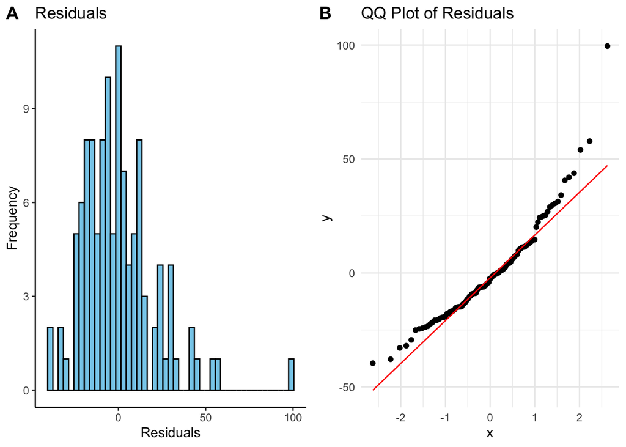

```r
ggarrange(histogram_plot, qq_plot,
          ncol = 2, nrow = 1,
          labels = c("A", "B"))
```

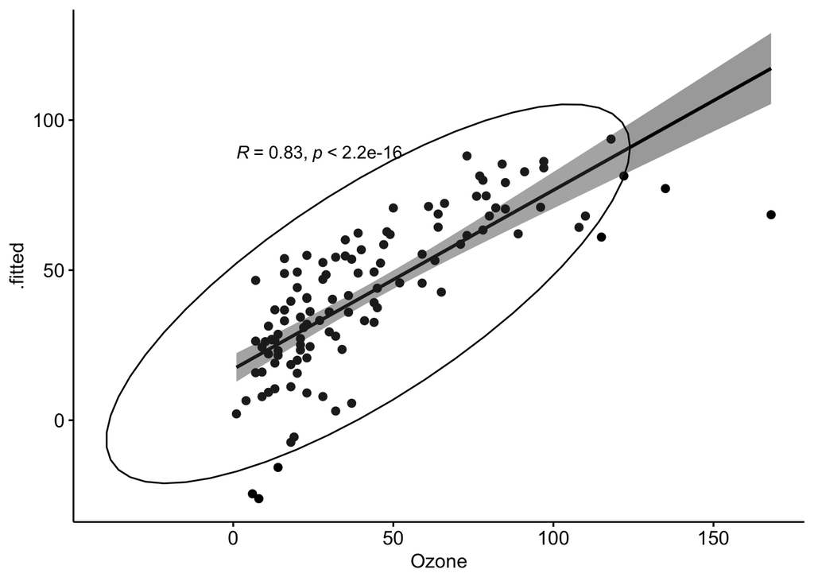

```r
ggscatter(pred,
         x = "Ozone", y = ".fitted",
         add = "reg.line", conf.int = TRUE,
         cor.coef = TRUE, cor.method = "spearman",
         ellipse = TRUE)
```